# EDA_J_Component

## Import Dataset

|  | Date(YYYY/MM/DD) | Time | Latitude | Longitude | Depth | Mag | Magt | Nst | Gap | Clo | RMS | SRC | EventID |
| --- | --- | --- | --- | --- | --- | --- | --- | --- | --- | --- | --- | --- | --- |
| 0 | 1966/07/01 | 09:41:21.82 | 35.9463 | -120.4700 | 12.26 | 3.20 | Mx | 7 | 171 | 20 | 0.02 | NCSN | -4540462 |
| 1 | 1966/07/02 | 12:08:34.25 | 35.7867 | -120.3265 | 8.99 | 3.70 | Mx | 8 | 86 | 3 | 0.04 | NCSN | -4540520 |
| 2 | 1966/07/02 | 12:16:14.95 | 35.7928 | -120.3353 | 9.88 | 3.40 | Mx | 8 | 89 | 2 | 0.03 | NCSN | -4540521 |
| 3 | 1966/07/02 | 12:25:06.12 | 35.7970 | -120.3282 | 9.09 | 3.10 | Mx | 8 | 101 | 3 | 0.08 | NCSN | -4540522 |
| 4 | 1966/07/05 | 18:54:54.36 | 35.9223 | -120.4585 | 7.86 | 3.10 | Mx | 9 | 161 | 14 | 0.04 | NCSN | -4540594 |
| ... | ... | ... | ... | ... | ... | ... | ... | ... | ... | ... | ... | ... | ... |
| 18025 | 2007/12/19 | 12:14:09.62 | 34.1438 | -116.9822 | 7.03 | 4.06 | ML | 10 | 73 | 14 | 0.08 | NCSN | 40207706 |
| 18026 | 2007/12/21 | 12:14:56.45 | 37.3078 | -121.6735 | 8.47 | 3.08 | ML | 114 | 45 | 5 | 0.12 | NCSN | 51192926 |
| 18027 | 2007/12/23 | 21:43:43.54 | 37.2127 | -117.8230 | 10.00 | 3.54 | ML | 45 | 176 | 40 | 0.07 | NCSN | 51193070 |
| 18028 | 2007/12/28 | 01:59:42.40 | 36.5292 | -121.1133 | 5.99 | 3.04 | ML | 70 | 45 | 4 | 0.06 | NCSN | 51193343 |
| 18029 | 2007/12/28 | 23:20:28.12 | 38.7710 | -122.7370 | 2.34 | 3.40 | Mw | 49 | 37 | 1 | 0.07 | NCSN | 51193419 |

18030 rows × 13 columns

## Preprocessing

No preprocessing required because the data is already clean and structured. We just have to change the column names to meaningful names.

|  | Latitude(deg) | Longitude(deg) | Depth(km) | Magnitude(ergs) | Magnitude_type | No_of_Stations | Gap | Close | RMS | SRC | EventID |
| --- | --- | --- | --- | --- | --- | --- | --- | --- | --- | --- | --- |
| 1966-07-01 09:41:21.820 | 35.9463 | -120.4700 | 12.26 | 3.20 | Mx | 7 | 171 | 20 | 0.02 | NCSN | -4540462 |
| 1966-07-02 12:08:34.250 | 35.7867 | -120.3265 | 8.99 | 3.70 | Mx | 8 | 86 | 3 | 0.04 | NCSN | -4540520 |
| 1966-07-02 12:16:14.950 | 35.7928 | -120.3353 | 9.88 | 3.40 | Mx | 8 | 89 | 2 | 0.03 | NCSN | -4540521 |
| 1966-07-02 12:25:06.120 | 35.7970 | -120.3282 | 9.09 | 3.10 | Mx | 8 | 101 | 3 | 0.08 | NCSN | -4540522 |
| 1966-07-05 18:54:54.360 | 35.9223 | -120.4585 | 7.86 | 3.10 | Mx | 9 | 161 | 14 | 0.04 | NCSN | -4540594 |
| ... | ... | ... | ... | ... | ... | ... | ... | ... | ... | ... | ... |
| 2007-12-19 12:14:09.620 | 34.1438 | -116.9822 | 7.03 | 4.06 | ML | 10 | 73 | 14 | 0.08 | NCSN | 40207706 |
| 2007-12-21 12:14:56.450 | 37.3078 | -121.6735 | 8.47 | 3.08 | ML | 114 | 45 | 5 | 0.12 | NCSN | 51192926 |
| 2007-12-23 21:43:43.540 | 37.2127 | -117.8230 | 10.00 | 3.54 | ML | 45 | 176 | 40 | 0.07 | NCSN | 51193070 |
| 2007-12-28 01:59:42.400 | 36.5292 | -121.1133 | 5.99 | 3.04 | ML | 70 | 45 | 4 | 0.06 | NCSN | 51193343 |
| 2007-12-28 23:20:28.120 | 38.7710 | -122.7370 | 2.34 | 3.40 | Mw | 49 | 37 | 1 | 0.07 | NCSN | 51193419 |

18030 rows × 11 columns

```
<class 'pandas.core.frame.DataFrame'>
DatetimeIndex: 18030 entries, 1966-07-01 09:41:21.820000 to 2007-12-28 23:20:28.120000
Data columns (total 11 columns):
 #   Column           Non-Null Count  Dtype
---  ------           --------------  -----
 0   Latitude(deg)    18030 non-null  float64
 1   Longitude(deg)   18030 non-null  float64
 2   Depth(km)        18030 non-null  float64
 3   Magnitude(ergs)  18030 non-null  float64
 4   Magnitude_type   18030 non-null  object
 5   No_of_Stations   18030 non-null  int64
 6   Gap              18030 non-null  int64
 7   Close            18030 non-null  int64
 8   RMS              18030 non-null  float64
 9   SRC              18030 non-null  object
 10  EventID          18030 non-null  int64
dtypes: float64(5), int64(4), object(2)
memory usage: 1.7+ MB
```

## Export Preprocessed dataset

Export the data into xlsx file

```
DataFrame is written to Excel File successfully.
```

## Partition the data into Training and Testing data

## Linear regression

### Loading the model and fitting it with training data

```
LinearRegression()
```

### Predict the testing data

Find the predicted values and evaluate it using metrics of linear regression

```
R^2: 0.03, MSE: 0.18
```

### Predict for new data

```
New predictions: [3.447483   3.33027751]
```

### Plot multiple linear regression model

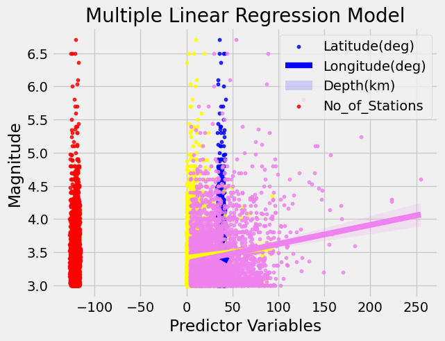

## SVM

### Loading the model and fitting it with training data

```
Test score: -1.9212973747969442
```

### Predict the testing data

Find the predicted values and evaluate it using metrics like MSE, r2

```
SVM R^2: -1.92, MSE: 0.53
```

### Predict for new data

```
New SVM predictions: [3.57401976 3.03496212]
```

### Plot model

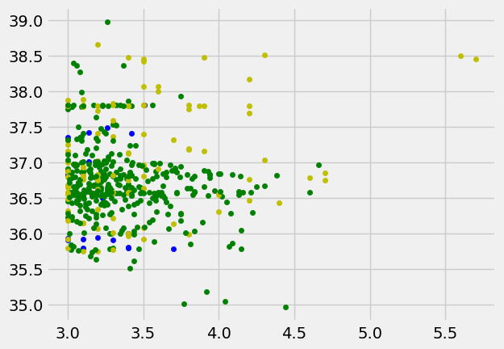

```
Index(['Latitude(deg)', 'Longitude(deg)', 'Depth(km)', 'Magnitude(ergs)',
       'Magnitude_type', 'No_of_Stations', 'Gap', 'Close', 'RMS', 'SRC',
       'EventID'],
      dtype='object')
```

```
array(['Mx', 'ML', 'Md', 'Mw'], dtype=object)
```

## Naive Bayes

> **Note: Naive bayes is used for strings and numbers(categorically) it can be used for classification so it can be either 1 or 0 nothing in between like 0.5 (regression). Even if we force naive bayes and tweak it a little bit for regression the result is disappointing; A team experimented with this and achieve not so good results.**

```
GaussianNB()
```

```
Accuracy: 0.9853947125161767
Confusion Matrix:
 [[5327   35    1]
 [  38    3    1]
 [   4    0    0]]
Classification Report:
               precision    recall  f1-score   support

       Minor       0.00      0.00      0.00         0
    Moderate       0.99      0.99      0.99      5363
      Strong       0.08      0.07      0.07        42
       Major       0.00      0.00      0.00         4

   micro avg       0.99      0.99      0.99      5409
   macro avg       0.27      0.27      0.27      5409
weighted avg       0.98      0.99      0.98      5409
```

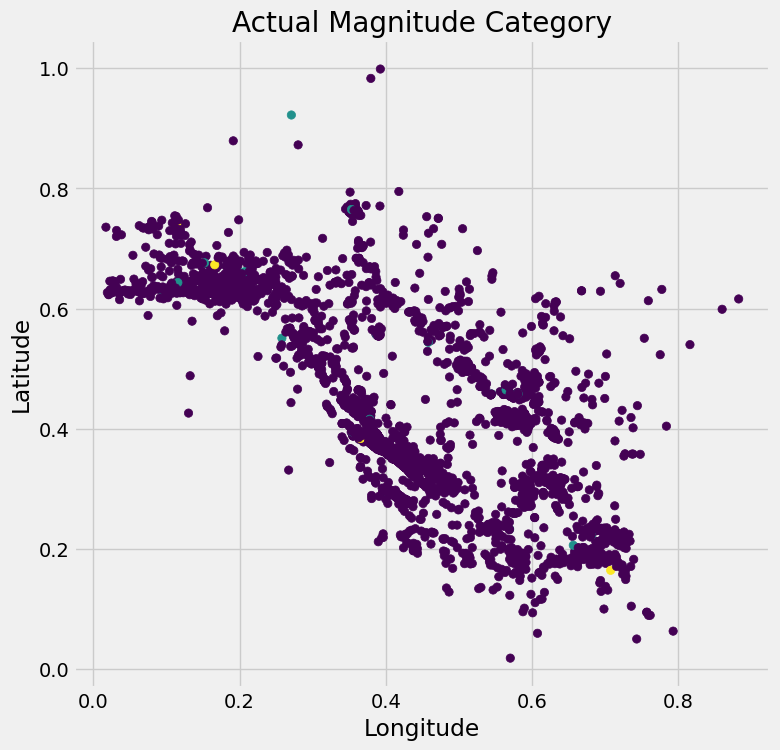

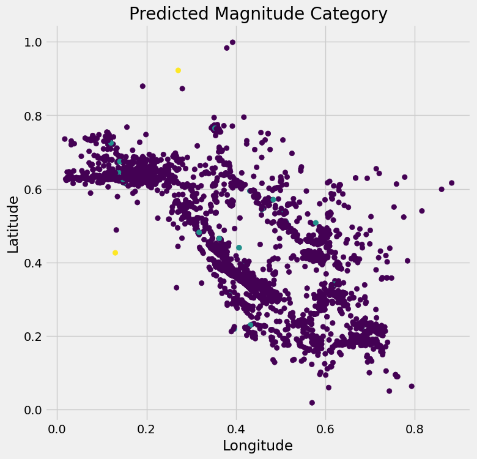

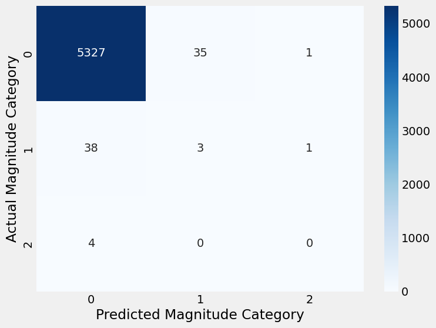

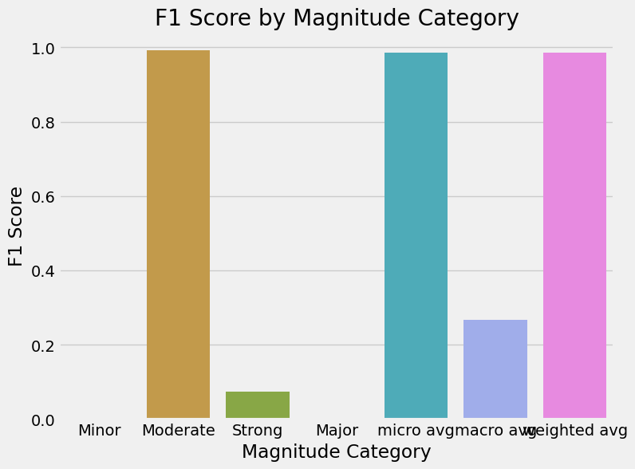

## Random Forest

### Loading the model and fitting it with training data

```
RandomForestRegressor(random_state=42)
```

### Predict the testing data and evaluate it

Find the predicted values and evaluate it using metrics like MSE, r2

```
Mean Squared Error:  0.15599116006378258
R^2 Score:  0.1428805732295345
```

### Plot model

**Scatter plot**

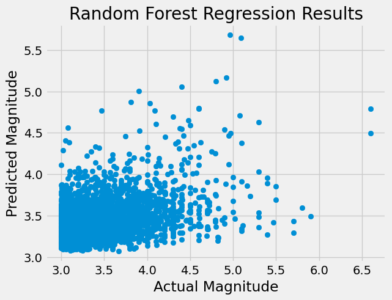

**Feature Importance**  
This plot shows the importance of each feature in the model. You can create a feature importance plot using the feature_importances_ attribute of the random forest model.

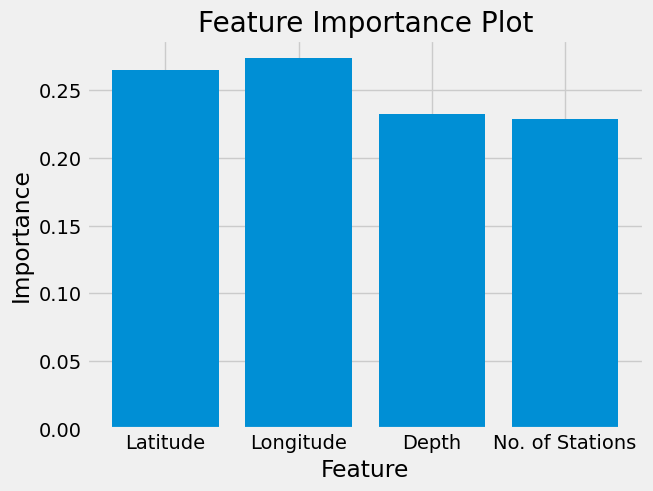

**Residual Plot**  
A residual plot shows the difference between the actual values and the predicted values. You can create a residual plot using the residplot() function from the seaborn library.

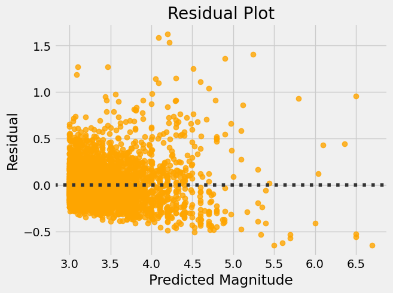

**Actual vs. Predicted Line Plot**  
Actual vs. Predicted Line Plot: A line plot can be used to show the trend of the actual and predicted values over time (if the data is time-series). You can create a line plot using the plot() function.

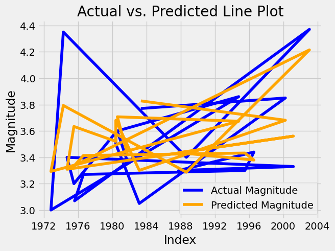

## Concluding the accurate model

|  | Model name | mse | R^2 |
| --- | --- | --- | --- |
| 0 | Linear regression | 0.175628 | 0.034983 |
| 1 | SVM | 0.531661 | -1.921297 |
| 2 | Random Forest | 0.155991 | 0.142881 |

|  | Model name | mse | R^2 |
| --- | --- | --- | --- |
| 0 | Linear regression | 0.175628 | 0.034983 |
| 1 | SVM | 0.531661 | -1.921297 |
| 2 | Random Forest | 0.155991 | 0.142881 |

|  | Model name | mse | R^2 |
| --- | --- | --- | --- |
| 2 | Random Forest | 0.155991 | 0.142881 |

|  | Model name | mse | R^2 |
| --- | --- | --- | --- |
| 2 | Random Forest | 0.155991 | 0.142881 |

From the above result we can conclude that random forest is the most accurate model for predicting the magnitude of Earthquake compared to all other models used in this project.